# Estimating Equations

**Example:** Consider the $\boldsymbol Z = (Z_1, \dots, Z_5)^\top$ with cdf
$$F(\boldsymbol z;\alpha) = \exp\left\{-\left(z_1^{-\frac{1}{\alpha}} + z_2^{-\frac{1}{\alpha}} + z_3^{-\frac{1}{\alpha}} + z_4^{-\frac{1}{\alpha}} + z_5^{-\frac{1}{\alpha}}\right)^\alpha\right\}, \quad \boldsymbol z \ge \boldsymbol 0, \alpha \in (0, 1].$$

Comments:

1. $F$ is max-stable.
2. $Z_1, \dots, Z_5$ are exchangeable.

Let’s consider the likelihood.

How about if we were to just use pairs of points to estimate $\alpha$?

If we just used $(z_{1i}, z_{2i}), i = 1, \dots, n$ would the likelihood based on the bivariate density be a good estimator for $\alpha$?

Let’s try it.

```r
library(evd)
# simulate data with alpha = 0.5
alpha <- 0.5
z <- rmvevd(500, dep = alpha, d = 5, mar = c(1, 1, 1))

## bivariate density
d_bivar <- function(z, alpha){
    #here "z" is a single observation (ordered pair)
    inside <- z[1]^(-1/alpha) + z[2]^(-1/alpha)
    one <- exp(-inside^alpha)
    two <- (z[1]*z[2])^(-1 / alpha - 1)
    three <- (1 / alpha - 1)*inside^(alpha - 2)
    four <- inside^(2 * alpha - 2)
    one*two*(three + four)
}

d_bivar(c(4, 5), alpha = alpha)
```

```
## [1] 0.003650963
```

```r
dmvevd(c(4,5), dep = alpha, d = 2, mar = c(1,1,1))
```

```
## [1] 0.003650963
```

```r
## estimate alpha
log_pair_lhood <- function(alpha, z) {
    #here "z" is bivariate matrix of observations
    inside <- z[, 1]^(-1 / alpha) + z[, 2]^(-1 / alpha)
    log_one <- -inside^alpha
    log_two <- (-1 / alpha - 1) * (log(z[, 1]) + log(z[, 2]))
    three <- (1 / alpha - 1) * inside^(alpha - 2)
    four <- inside^(2 * alpha - 2)
    contrib <- log_one + log_two + log(three + four)
    return(sum(contrib))
}

all_pairs_lhood <- function(alpha, z) {
    expand.grid(dim1 = seq_len(ncol(z)),
                dim2 = seq_len(ncol(z))) |>
      filter(dim1 < dim2) |>
      rowwise() |>
      mutate(log_pair_lhood = log_pair_lhood(alpha, cbind(z[, dim1], z[, dim2]))) |>
    ungroup() |>
      summarise(res = sum(log_pair_lhood)) |>
      pull(res)
}

alpha_mple <- optim(.2, lower = .01, upper = .99, all_pairs_lhood, z = z, method = "Brent", hessian = TRUE, control = list(fnscale = -1))
(ci_mple <- alpha_mple$par + c(-1.96, 1.96)*sqrt(-1 / alpha_mple$hessian[1, 1]))
```

```
## [1] 0.4954979 0.5182678
```

[output not shown]

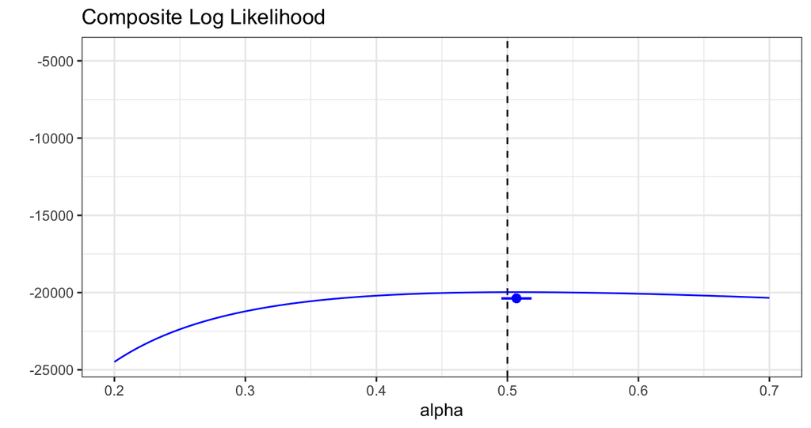

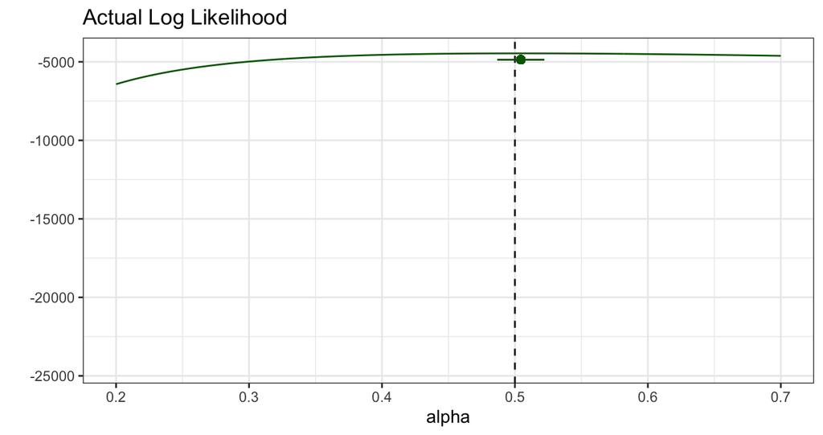

```r
## checking coverage
#checking coverage
B <- 200
coverage <- numeric(B)
for(k in seq_len(B)) {
    z_k <- rmvevd(500, dep = .5, d = 5, mar = c(1, 1, 1))
    alpha_mple_k <- optim(.2, lower = .01, upper = .99, all_pairs_lhood, z = z_k, method = "Brent", hessian = TRUE, control = list(fnscale = -1))
    ci <- alpha_mple_k$par + c(-1.96, 1.96)*sqrt(-1 / alpha_mple_k$hessian[1, 1])
    coverage[k] <- as.numeric(ci[1] < alpha & ci[2] > alpha)
}
mean(coverage)
```

[output not shown]

So, it looks like the point estimate from the pairwise likelihood is ok, but we need to be able to get an appropriate measure of uncertainty.

# 1 Introduction

M-estimators are solutions of the vector equation
$$\sum\limits_{i = 1}^n \boldsymbol \psi(\boldsymbol Y_i, \boldsymbol \theta) = \boldsymbol 0.$$

In the likelihood setting, what is $\boldsymbol \psi$?

**Example:** Let $Y_1, \dots, Y_n$ be independent, univariate random variables. Is $\theta = \overline{Y} = \frac{1}{n}\sum\limits_{i = 1}^n Y_i$ an M-estimator?

**Example:** Consider the mean deviation from the sample mean,
$$\hat{\theta}_1 = \frac{1}{n} \sum\limits_{i = 1}^n |Y_i - \overline{Y}|.$$
Is this an M-estimator?

# 2 Basic Approach

M-estimators are solutions of the vector equation
$$\sum\limits_{i = 1}^n \boldsymbol \psi(\boldsymbol Y_i, \boldsymbol \theta) = \boldsymbol 0.$$
but what are they estimating?

**Example (Sample Mean, cont’d):** Recall we said $\theta = \overline{Y} = \frac{1}{n}\sum\limits_{i = 1}^n Y_i$ is an M-estimator for $\psi(Y_i, \theta) = Y_i - \theta$. What is the true parameter?

To arrive at the sandwich estimator, assume $\boldsymbol Y_1, \dots, \boldsymbol Y_n \stackrel{iid}{\sim} F$ and define
$$\boldsymbol G_n(\boldsymbol \theta) = \frac{1}{n}\sum\limits_{i = 1}^n \boldsymbol \psi(\boldsymbol Y_i; \boldsymbol \theta).$$

Define $\boldsymbol A(\boldsymbol \theta_0) = \text{E}_F[-\boldsymbol \psi'(\boldsymbol Y_1, \boldsymbol \theta_0)]$.

## 2.1 Estimators for $\boldsymbol A, \boldsymbol B$

One of the key contributions of M-estimation theory is to point out what happens when the assumed parametric family is not correct.

We can use empirical estimators of $\boldsymbol A$ and $\boldsymbol B$:

**Example (Coefficient of Variation):** Let $Y_1, \dots, Y_n$ be idd from some distribution with finite fourth moment. The coefficient of variation is defined at $\hat{\theta}_3 = s_n / \overline{Y}$.

Define a three dimensional $\boldsymbol \psi$ so that $\hat{\theta}_3$ is defined by summing the third component. What is the vector valued function $\boldsymbol \psi$ which yields an M-estimator for the coefficient of variation?

What parameter vector is being estimated by the M-estimator?

What are the matrices $\boldsymbol A$ and $\boldsymbol B$?

Write out the asymptotic variance, $\boldsymbol V$.

Assume $Y_i$ are iid from a normal distribution with mean $10$ and standard deviation $1$. Calculate $V_{3,3}$. Assume you have a same of size $25$ and you get an estimated coefficient of variation of $0.11$. Give the asymptotic $95$% confidence interval.